# Developing a framework for responsible downsizing through best fit: the importance of regulatory, pr

#### **Developing responsible downsizing: what do we know?**

An important premise of previous research is that downsizing has become the primary response to competitive or recessionary pressures as it is typically framed as the natural course of action (McKinley et al., 2000). At the employee level, a key debate relates to ‘victims’, ‘survivors’ and ‘endurers’ (Brockner, 1992; Brockner et al., 2004; De Vries & Balazs, 1997; McLachlan et al., 2021). Victims exit an organisation and can suffer loss of salary and the scarring effects of unemployment. Survivors and endurers both remain employed at the organisation, though the latter is distinct as they experience internal redeployment: both can experience negative work-related attitudes and career disruption. In this sense, our existing understanding of responsible downsizing is informed by these employee experiences, which have illuminated the extent to which organisations treat the workforce in fair and responsible fashion (Teague & Roche, 2014; Van Dierendonck & Jacobs, 2012). Other studies have also pointed to potential strategic benefits associated with a responsible approach (Tsai & Yen, 2020).

Research into responsible downsizing has spread across business and management literature, and a variety of terminology has described the topic: socially responsible restructuring (Forde et al., 2009); responsible restructuring (Cascio, 2002; Johnstone, 2019; Teague & Roche, 2014); socially responsible workforce reduction (Bergström, 2007); social responsibility in downsizing (Bergström & Diedrich, 2011; Van Buren, 2000); social responsibility in business closures (Ahlstrand, 2010); CSR in restructuring (Bonvin, 2007); ethical downsizing (Hopkins & Hopkins, 1999; Long, 2012); corporate responsibility in lay-offs (Kieselbach &

Page 5

The International Journal of Human Resource Management 19

Mader, 2002); CSR in closedowns (Rydell & Wigblad, 2011; Snell & Gekara, 2020); and responsible downsizing strategy (Tsai & Shih, 2013a, 2013b; Tsai & Yen, 2020). While the use of terms such as ‘ethics’ and ‘responsibility’ are useful indicators of the behaviours and actions of organisations, one problem with these previous studies is a lack of detail about what ‘responsibility’ means in downsizing. That is, the extent to which different *types* of responsibility may be evident during downsizing is less refined in previous constructions of responsible downsizing. Therefore, this paper builds on these previous studies by taking inspiration from similar conceptual developments in the CSR literature where responsibility has been nuanced to recognise different types of responsibility: economic, legal, ethical, philanthropic (Carroll & Shabana, 2010) and political responsibilities (Scherer & Palazzo, 2007). Illuminating different types of responsibilities, as opposed to a blanket notion of ethics or responsibility, arguably deepens our knowledge about what a responsible downsizing entails and may aid organisations in determining the practices required to enact such a process.

Nevertheless, there have been attempts at defining responsible approaches to downsizing. The process has been viewed as a set of practices that form an anticipatory strategy involving on-going social dialogue and negotiation over the effects of downsizing (Forde et al., 2009), or as a strategy that underpins the fairness of management actions as a means of preserving a positive psychological contract (Teague & Roche, 2014). Further, Van Buren (2000) argued that perceptions of responsibility reflect the level of ‘bindingness’ of social and psychological contracts, determining a moral expectation as to how each party should act: the higher the level of bindingness the greater the responsibility. However, downsizing is typically a unilateral managerial process that reflects power imbalances in the employment relationship (Cullinane & Dundon, 2006). Downsizing is disproportionately experienced by employees as they bear the brunt of its impact, which arguably puts greater emphasis on employers’ ability to manage the process responsibly.

Crucially, a dominant feature of policy literature is toolbox-like best practices for organisations to implement as part of responsible downsizing. These practices include but are not limited to: employability initiatives; outplacement services; skills investment; meaningful and effective communication; counselling services; internal redeployment; generous severance packages; early retirement; voluntary redundancy; alternative redeployment schemes; job search assistance; provision of financial advice; legal compliance and enterprise start-up workshops. These have been incorporated at institutional level by the International Labour Office and the European Commission, who have set practical

Page 6

20 C. J. MCLACHLAN

guidance (Auer, 2001; CEDEFOB, 2010; EC, 2009; Evans-Klock et al., 1998; Hansen, 2009; MIRE, 2006; Papadakis, 2010; Rogovsky et al., 2005). There are also support mechanisms at European and US level instituted through the European Globalisation Adjustment Fund and the US Trade Adjustment Assistance programmes (Stuart et al., 2007). What is unclear from the policy literature, however, is whether the incidence of ‘responsible’ downsizing practices is a useful indicator of the overall responsibility of the process, or what types of responsibility motivate organisations to adopt certain practices.

Research by Bergström (2007) sets out a valuable contribution to the topic by arguing that best practices require *translation* into local contexts if a responsible process is to be assumed. Importantly, Bergström (2007, p. 386) states that responsible practices cannot be ‘picked up and applied anywhere’. This paper follows Bergström (2007) in questioning the assumptions that underpin the dominant best practice focus in academic and policy downsizing literature. In researching an ostensible responsible downsizing process at Vattenfall, a Swedish state-owned company, Bergström (2007) highlights how best practices were imitated from other Swedish firms but repackaged into a ‘responsible’ model based on key principles driving Vattenfall’s downsizing process. Such principles focussed on working closely with unions to ensure as few redundancies as possible and that, where possible, compulsory redundancies were avoided through the provision of voluntary redundancy arrangements. In analysing the translation of best practices to the Vattenfall context, Bergström (2007) usefully argues that responsible downsizing is entrenched in institutionalised norms and is therefore not a static model that can be successfully adopted anywhere. However, how a process of translation might be achieved by organisations conducting responsible downsizing is less developed. While responsible downsizing is not a stable model, some standards or principles are nonetheless necessary to understand the dynamics that underpin such a process and advance knowledge of the topic.

Furthermore, it is unclear how Bergström’s (2007) analysis differs from theories of best practice versus best fit in the HRM literature. Given downsizing is typically conducted by the HR function (Sahdev et al., 1999), it is worth reflecting on how related theories may provide a useful conceptual lens to understand responsible downsizing. In reflecting on these, best practice approaches suggest a universally applicable set of practices that enhance organisational performance across multiple contexts. In contrast, and analogous to Bergström’s (2007) notion of translation, best fit approaches view the ‘success’ of HR practices as mediated by contextual variables. A best fit approach does not reject the value of best practices, but rather acknowledges the interplay between

Page 7

The International Journal of Human Resource Management 21

**Table 1.** Search terms.

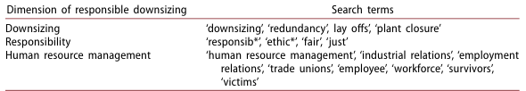

NOTE: complex table shown as an image of the PDF; the text below is a rough machine extraction and may be mis-aligned.

**extracted text (unreliable layout)**

best practices and the local contexts in which they are applied (Purcell, 1999; Stavrou et al., 2010). Nonetheless, the doubt cast over best practice approaches due to a lack of concern for the influence of context (Marchington & Grugulis, 2000) hence raises similar doubts over its utility in relation to responsible downsizing. In this sense, drawing on HR theories of best practice and best fit offers a route to deepening our knowledge of how the adoption of ‘responsible’ downsizing practices vary depending on the external and internal contexts shaping their implementation.

#### **Systematic review method**

The systematic review was informed by Tranfield et al. (2003) and utilised academic search databases: *Scopus*, *Business Source Premier*, *Web of Science* and *Google Scholar*. Other downsizing-related review articles were also mined for relevant articles, along with searches in key HRM journals such as *Human Resource Management Journal*, *Human Resource Management* and the *International Journal of Human Resource Management.* The search terms were split into three dimensions of ‘downsizing’, ‘responsibility’ and ‘human resource management’, detailed in Table 1. Combinations of these three dimensions were configured and provided a targeted search.

An inclusion and exclusion protocol were established (Tranfield et al., 2003) which is presented alongside the logic for the criteria in Tables 2 and 3. Only articles based on empirical research were included. The justification for this was to develop a review based on concrete examples of different downsizing contexts. Articles on survivors and victims had to involve some discussion of the downsizing *process* rather than only employee impact. An important distinction was identifying the types of ‘responsible’ practices implemented to ameliorate the impact of downsizing, which are arguably antecedent to the employee impact. Some articles involved an overlapping discussion of both the downsizing process and employee outcomes. Where such an overlap was evident in an article it was considered for inclusion.

Overall, 44 articles were reviewed and thematically analysed. An inductive approach was adopted and involved two coding cycles (Tracy,

Page 8

22 C. J. MCLACHLAN

2019). A first cycle of coding involved making detailed comments on pdf files of the articles that fractured the material into concrete, discrete practices. Once the articles were coded for different practices, these were then contrasted with ‘best practices’ in the policy literature to cross-reference for consistency. A second cycle of coding identified patterns of responsible practice in the articles and lumped these together as a way to develop thematic categories. Further written notes were made in this second cycle that explained how contextual variables shaped the implementation of best practices: this stage helped address the research question around the best fit approach. Discussion of downsizing practices in the review articles was generally framed by specific national or sectoral contexts. A further process of interpretation then abstracted the coded practices into clusters to refine the construction of themes by capturing their wider purpose. For example, evidence of extended consultation periods reflected an augmentation of regulatory compliance, or how outplacement programmes demonstrated a responsibility for employment transitions. The discovery of themes represented different types of responsibility and were defined as the *regulatory, procedural, communication* and *employment* responsibilities of organisations.

**Table 2.** Article inclusion criteria.

Article inclusion protocol

*Criteria Logic* Date The range was set from 1984 to 2020. The lower range

reflected the earliest article found on responsible downsizing, with the upper range set at 2020 to account for contemporary empirical research published online. Empirical articles Articles had some element of primary or secondary data

based on concrete examples of downsizing processes. Examination of organisational downsizing

process

Articles had to be concerned with downsizing where

employees were made redundant as a result. Focus on specific practices intended to

ameliorate employee outcomes

Articles had to focus on the specific organisational

practices that were implemented during downsizing, and that were intended to ameliorate the consequences of redundancy. Downsizing discussed alongside issues of

responsibility, fairness, justice or ethics

Articles had to analyse downsizing, either the whole

process or a feature of it, in relation to some aspect of responsibility.

**Table 3.** Article exclusion criteria.

Article exclusion protocol

*Criteria Logic* Conceptual articles Discursive or conceptual articles were useful in framing the topic but

were excluded from the review given the focus concrete examples of downsizing practices. Employee experiences Articles that analysed individual employee experiences of redundancy ‘Survivors’ and ‘Victims’ research Articles solely addressing the implications of downsizing for

‘survivors’ and ‘victims’ were excluded as the focus of the review is on the downsizing process rather than outcomes. Practitioner reports These are sometimes of an unreliable quality and do not undergo

peer-review.

Page 9

The International Journal of Human Resource Management 23

Table 4 provides an overview of the reviewed articles and an index as to responsibilities each article corresponded with. Many articles were consistent with more than one type of responsibility which illustrated their overlapping and often mutually reinforcing nature: some practices support more than one responsibility. The next section explores these responsibilities and the best fit approach as part of a framework for responsible downsizing.

#### **Downsizing practices and types of responsibility: a best fit approach**

*Regulatory responsibilities* A core obligation when downsizing is compliance with *regulatory responsibilities* in the external environment. Regulation exists in national legislation and through supranational bodies such as the EC and the ILO. National statutory provisions around downsizing are ‘harder’ than supranational regulation as organisations must comply, though both offer protection to employees. For downsizing to be considered ‘responsible’, legal compliance represents a minimum behavioural standard (Bonvin, 2007; Mäkelä & Näsi, 2010). ‘Soft’ forms of regulation from supranational bodies are generally understood as best practice despite organisations not compelled to comply. Nevertheless, that basic legal compliance is viewed as necessary for responsible downsizing could be seen as an indictment on the reality of responsible organisational activity as it is arguably the least employees should expect.

In terms of best fit, what is perceived as responsible downsizing in one context is not necessarily so in another (Bergström, 2007). Regulation varies across and *within* nations, relating to length of employee consultation and trade union influence along with the degree of stakeholder engagement. Research into downsizing has indicated how national and institutional regulatory contexts may enable or constrain the management of the process (Bergström, 2007; De Witte et al., 2005; Garaudel et al., 2008; Johnstone, 2019; Kirov & Thill, 2018; Mäkelä & Näsi, 2010; Pulignano, 2011; Snell & Gekara, 2020). For instance, research points to the role of negotiations with unions over downsizing in terms of regulatory norms or values. The involvement of unions also overlaps with internal procedures and communication practices, discussed below, with supporting evidence from Taiwan (Tsai & Shih, 2013a), Australia (Snell & Gekara, 2020) and across Europe more widely (Kirov & Thill, 2018; Pulignano, 2011). An issue lacking a focussed discussion in extant research is that in some countries, or sectors, certain norms and values related to responsible downsizing may already be embedded within organisational and

Page 10

24 C. J. MCLACHLAN

**Table 4.** Review articles and types of responsibility.

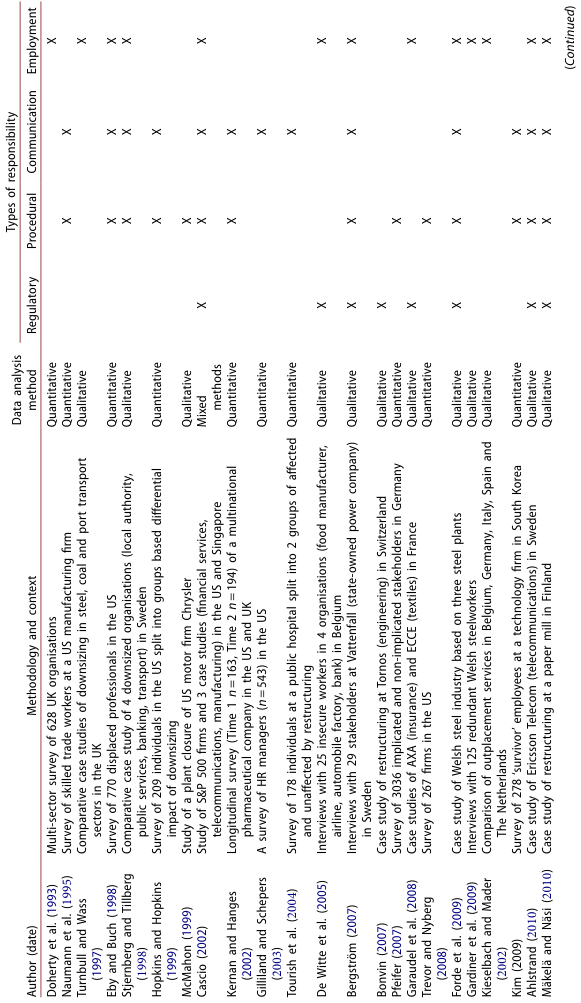

NOTE: complex table shown as an image of the PDF; the text below is a rough machine extraction and may be mis-aligned.

**extracted text (unreliable layout)**

Page 11

The International Journal of Human Resource Management 25

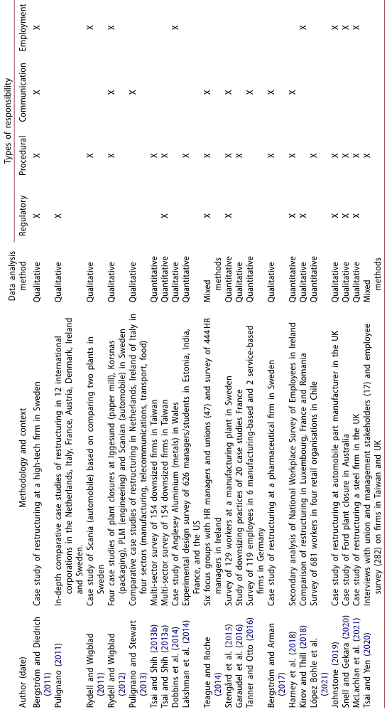

NOTE: complex table shown as an image of the PDF; the text below is a rough machine extraction and may be mis-aligned.

**extracted text (unreliable layout)**

**Table 4.** Continued.

Page 12

26 C. J. MCLACHLAN

institutional contexts. This may determine whether a process can be described as responsible as different contexts potentially make supposed ‘best practices’ more or less noticeable. For example, a negotiated approach involving bipartite and tripartite agreements between the state, employers and unions around downsizing exists in Nordic countries, reflecting a customary approach to managing downsizing responsibly (Ahlstrand, 2010; Bergström, 2007; Bergström & Diedrich, 2011). In comparison, market driven regimes with minimum regulation such as the UK or US, despite pockets of voluntarist collective regulation existing, mean cases of responsible downsizing may be more celebrated (Forde et al., 2009; Johnstone, 2019; McLachlan et al., 2021).

A common regulatory feature that also reinforces the nature of communicatory practices when downsizing is the presence of consultation with affected employees. Although the scope varies, work by Kernan and Hanges (2002) and Harney et al. (2018) has demonstrated that consultation buffers negative experiences of downsizing and improves employee well-being. Intensive or extensive forms of consultation may reflect responsible downsizing by promoting greater understanding of the process, which in turn elicits perceptions of enhanced support for employees (Harney et al., 2018). Other research has pointed to the positive role of longer consultation periods in building greater time into downsizing for management to deal with its effects on employees and engage with stakeholders, especially in relation to employment transitions (Rydell & Wigblad, 2011, 2012; Ahlstrand, 2010). However, there is little critical reflection on potentially cynical uses of consultation periods, such as through management attempts to implement unplanned redundancies as longer downsizing processes progress (McLachlan et al., 2021). The utility of statutory consultation periods in supporting responsible downsizing is not evident from extant research. Most cases reviewed involve extended consultation periods typically predicated upon discrete, non-statutory, forms of collective regulation.

Examples of organisations going ‘beyond’ minimal compliance with local laws or regulations offer support for a best fit approach and interact with employability concerns of those affected. Research by Ahlstrand (2010) into Ericsson Telecom in Sweden demonstrated that surpassing legal requirements generated positive perceptions among stakeholders. Employees were offered twelve months of support with employment transitions and subsidised salaries that went further than the legally required six month notice period. Another example in the UK steel sector was the collectively regulated provision of severance packages above statutory level. Due to the demanding nature of working in steel as manual workers get older, severance packages were twinned with early retirement agreements. This offered enhanced financial

Page 13

The International Journal of Human Resource Management 27

support to employees while also encouraging voluntary redundancy (Forde et al., 2009; McLachlan et al., 2021), which has typically been viewed as a more responsible approach (Johnstone, 2019).

#### *Procedural responsibilities*

The regulatory responsibilities discussed above largely relate to external environments. Research has also illustrated how organisations might adopt *internal* processes and procedures that recognise the strategic benefits of responsible downsizing. In this sense, the establishment of formalised procedures, such as through company policy documentation, can contribute to the realisation of responsible downsizing (Cascio, 2002; Forde et al., 2009; Rydell & Wigblad, 2011, 2012). The need to make responsible downsizing *visible* to employees is seen as an attempt to substantiate its implementation. Finding a way to demonstrate a *procedural responsibility* when managing downsizing can aid organisations in gaining favour of stakeholders by formally integrating them into the process. What seems important is that procedures circumscribing downsizing are perceived as fair, avoiding accusations of ‘foul play’. However, the extent to which formal procedures reflect a managerialist narrative of responsibility has been questioned (Bergström & Diedrich, 2011), as it cannot be assumed they equate to improved employee outcomes and may simply be a facade. Nonetheless, for organisations to differentiate a responsible downsizing process from a more general one (Cascio, 2002; Tsai & Shih, 2013a, 2013b), they typically require the implementation of a series of demonstrably ‘responsible’ procedures that reflect local circumstances.

The timing of downsizing has also proved an important aspect of procedural responsibility. Work by Forde et al. (2009) emphasises the need for organisations to establish an overarching timeline. This approach illustrates what practices to implement and *when*, and which may also act as a signal to employees of a formalised procedure: the period before the announcement of redundancies; the announcement of redundancies in tandem with the commencement of consultation periods; and the implementation of redundancies. Furthermore, research by Rydell and Wigblad (2011, 2012) into the Swedish automobile sector propose a process model that locates downsizing as a feature of CSR strategy. One outcome is an extended process that provides organisations and employees with longer to adjust to downsizing, which acts to reinforce the extent of support in employment transitions. The significance of more time to develop downsizing procedures is also supported by McMahon’s (1999) account of Chrysler in the US. An initial judgement of ‘irresponsibility’ from local government officials was reversed after the

Page 14

28 C. J. MCLACHLAN

company changed strategy and enacted due process along with a plan to improve local labour market opportunities for those affected.

As discussed, extant research views processes that extend beyond minimum regulatory requirements as a broadly beneficial best practice. That said, internal managerial objectives of downsizing may also shift as longer processes increase the possibility of other structural constraints emerging, such as end of financial year deadlines or strained HR capabilities (McLachlan et al., 2021), which risk undermining a commitment to a responsible approach. A blanket best practice assumption of greater temporality in the delivery of downsizing may therefore fail to recognise its susceptibility to change by HR or senior management as the process progresses.

Procedural responsibility in downsizing is also evident in relation to upholding justice for employees. Research has highlighted the importance of procedural, distributive, informational and interactional justice in the course downsizing (Kernan & Hanges, 2002; Lakshman et al., 2014; López Bohle et al., 2021; Naumann et al., 1995; Stjernberg & Tillberg, 1998; Trevor & Nyberg, 2008; Tsai & Yen, 2020). A fuller discussion of justice is beyond this paper. However, employees and stakeholders are more likely to perceive the process fair if ‘proper’ procedures have been seen to be followed. Heightened perceptions of responsibility amongst employees and stakeholders can be generated if procedural aspects such as selection criteria, transparency and accuracy of information, sufficient compensation policies and employee involvement are seen to be delivered equitably. Subsequently, perceptions of fairness can enhance the motivation and commitment of the post-downsizing workforce (Lakshman et al., 2014; McLachlan et al., 2021; Teague & Roche, 2014). Where the utility of a best fit approach becomes further apparent is with regards to implementing procedures in a way that treats employees with respect and dignity on an interpersonal level. Stjernberg and Tillberg (1998) highlight that best practice instructs management to support employees throughout the process, calling for greater sensitivity given the potential distress caused. A responsible approach therefore involves increased social and empathetic capabilities when managing the variety of human emotions downsizing produces, which may not always be achieved through a standardised best practice procedure.

Despite research indicating HR practices play a role in moderating perceptions of procedural fairness (Hopkins & Hopkins, 1999; Teague & Roche, 2014; Trevor & Nyberg, 2008), perceptions of justice remain highly contingent, which reflects the value in adopting a best fit approach. Such perceptions are shaped by age, gender, tenure and skill level or sectoral norms and values. While best practices in terms of procedural issues such as advance warning periods (Eby & Buch, 1998), severance

Page 15

The International Journal of Human Resource Management 29

pay (Garaudel et al., 2016) or employee involvement (Bergström & Arman, 2017; Pfeifer, 2007) exist, not all of them are of equivalent value to employees. A best fit approach can hence explain how the prioritisation of different practices amongst organisations are determined by the variable characteristics of the workforce, as opposed an application of uniform best practices.

#### *Communication responsibilities*

An essential feature of responsible downsizing involves HR and management ensuring employees, and their representatives, are involved in the process. In addition to communicatory practices reinforcing regulatory and procedural responsibilities, such as negotiation processes and consultation periods, a further theme focuses on how *communication responsibilities* can enhance perceptions of fairness (Bergström & Arman, 2017; Eby & Buch, 1998; Hopkins & Hopkins, 1999; Kernan & Hanges, 2002; Kim, 2009; Pulignano & Stewart, 2013; Stengård et al., 2015; Tanner & Otto, 2016; Tourish et al., 2004). Key to communication is information sharing that ranges from minimal updates to strategic or financial rationales for downsizing. As outlined by Tourish et al. (2004) in the healthcare sector, communication depends on the degree to which employees are affected. For instance, ‘victims’ may need detailed information about termination arrangements and available support delivered in a delicate manner, whereas ‘survivors’ may require reassurances on job security and workloads post-downsizing. Communication arguably needs to combine transactional information sharing with a concern for an interpersonal style of interaction not always captured by set scripts.

Other research has stressed the role unions play in delivering communicative practices in terms of early negotiations with management and ongoing employee support, which overlaps with regulatory or procedural concerns (Forde et al., 2009; Garaudel et al., 2008; Kirov & Thill, 2018; McLachlan et al., 2021; Tsai & Shih, 2013b). Where unions are present, they can influence the process and seek to incorporate mechanisms of communication that offer guidance to employees. Given unions often have closer interpersonal relationships with employees (Forde et al., 2009; McLachlan et al., 2021) their role can augment the supportive function of communicatory practices and reduce the managerial one-sidedness of downsizing (Teague & Roche, 2014). The lack of widespread union recognition, and sometimes low national levels of union density, nevertheless raises the question as to the possibility of responsible downsizing in non-unionised contexts or through other forms of employee representation, both of which require further exploration.

Page 16

30 C. J. MCLACHLAN

Communicatory practices also provide a ‘buffering’ effect between management and employees when addressing the impact of downsizing (Harney et al., 2018; Naumann et al., 1995; Tanner & Otto, 2016). Tanner and Otto (2016) suggest that effective communication is a just means of addressing potential resistance to change wrought by downsizing. A failure to communicate with employees over downsizing may jeopardise procedural and regulatory responsibility, and if critical information is withheld organisations risk being perceived as unethical or irresponsible (Hopkins & Hopkins, 1999). Crucial for responsible downsizing is therefore open communication that eases employee transitions during what can be a tense situation (Eby & Buch, 1998; Forde et al., 2009; Teague & Roche, 2014). However, the dynamics of what a meaningful, interpersonal approach to communication looks like in practice is unclear, despite broad acknowledgement that employees should be permitted opportunities to ask questions and vent personal grievances as downsizing progresses.

Research has also pointed to the relationship between communication and improved informational justice (Kernan & Hanges, 2002; Kim, 2009; Stengård et al., 2015). Informational justice is the extent to which managerial decisions, such as downsizing, are seen as fair and delivered through honest interactions. Where a heightened perception of informational justice exists, extant research has indicated improved well-being and less negative attitudes towards downsizing (Gilliland & Schepers, 2003; Stengård et al., 2015). While the quality of communicative practices is a vital support mechanism for victims of downsizing (Naumann et al., 1995), research by Kernan and Hanges (2002) points to the knock-on effects that positive perceptions of fairness can have on survivors who are more likely to view the organisation favourably as a result; similar to procedural justice.

A best fit approach reveals that although ‘effective’ communication is universally accepted as best practice, the nature of communication is conditioned by the prevailing employment relations climate and the associated power imbalances (Bergström, 2007; Bergström & Diedrich, 2011; Tanner & Otto, 2016). One related assumption made around responsible downsizing is the need for ongoing dialogue (Forde et al., 2009). Organisations may initiate formal communication channels established through HR, senior managers or unions. What is less clear is whether forms of communication are hastily developed on a temporary or bespoke basis, initiated for the purpose of downsizing only, or expand upon pre-existing mechanisms. Nevertheless, what form ongoing dialogue might take in practical terms in responsible downsizing has been underexplored, though could involve establishing forums or committees dedicated to discussing the effects on the post-downsizing workforce.

Page 17

The International Journal of Human Resource Management 31

#### *Employment responsibilities*

Providing employment-related support such as help with job transitions and retraining have been an historical best practice in downsizing. Redundancy can cause a sense of loss, primarily in employment and income with attendant effects in terms of career disruption and scarring effects (Gardiner et al., 2009; Turnbull & Wass, 1997). This is especially the case for victims of downsizing, though as noted survivors rarely emerge unharmed. Research has therefore considered the practices taken to mitigate such effects, categorised as an organisation’s *employment responsibilities* during downsizing (De Witte et al., 2005; Doherty et al., 1993; Eby & Buch, 1998; Forde et al., 2009; Kieselbach & Mader, 2002; Kirov & Thill, 2018; McLachlan et al., 2021; McMahon, 1999; Snell & Gekara, 2020; Trevor & Nyberg, 2008).

A priority in extant research has been the identification of measures that ensure labour market re-entry and avoid long-term unemployment for those affected. Academic research has developed in parallel with the best practice nature of the policy agenda, focussing on practices such as retraining and reskilling through outplacement services and other employability initiatives such as CV writing, interview training or enterprise start-up workshops (De Witte et al., 2005; Dobbins et al., 2014; Doherty et al., 1993; Forde et al., 2009; Kieselbach & Mader, 2002). In doing so, organisations engage with different stakeholders such as external skills and training agencies or government bodies, which may also complement the existence of internal downsizing procedures.

Work by Kieselbach and Mader (2002) sought to advance a European model of outplacement and views such practices as part of a CSR strategy that aids employment transitions for those displaced. The provision of support has received criticism due its limited applicability in certain regional or national contexts. Reskilling and retraining can be mismatched with the needs of employees and local economies, leading to equivocal prospects for those affected (Dobbins et al., 2014). While research points to an ethical duty on organisations to proactively support employees’ careers post-downsizing, this is constrained by contextual factors such as individual biographies and availability of opportunities in local labour markets (Dobbins et al., 2014; Gardiner et al., 2009; McLachlan et al., 2021). Viewing employment responsibilities through a best fit approach considers not just the needs of employees but the relationship of their human capital to local or national external labour markets. Moreover, the potential for responsible downsizing depends on the efficacy of employment transition programmes, which are typically shaped by the strength of regulation and availability of institutional support, along with the extent to which provision is embedded in

Page 18

32 C. J. MCLACHLAN

national regimes and downsizing norms (Bergström, 2007), and whether HR has an ‘ethical’ orientation (Forde et al., 2009).

In addition, research has explored practices that avoid redundancies (Forde et al., 2009; Johnstone, 2019; McLachlan et al., 2021), which are indicative of a responsible approach as they retain employment for those affected. One practice conducted primarily through HR mechanisms is redeployment strategies that offer alternative employment internally. Internal redeployment is a feature of best practice toolboxes and in some countries overlaps with prevailing regulations or law, with the underlying goal of securing *any* type of employment to avoid unemployment. Nonetheless, research has highlighted how internal redeployment has arguably been extended due to best fit considerations and sometimes developed into a sophisticated practice that reflects a strategic focus on a fair and just approach to the management of downsizing (Johnstone, 2019; McLachlan et al., 2021) while shielding employees from the vagaries of the external labour market. Work by McLachlan et al. (2021) on ‘endurers’ has advanced insights into the role of HR in redeployment. The authors highlight unresolved challenges such as whether endurers view redeployments as suitable and consistent with their skillsets and competencies. Such an approach puts greater demands on HR’s ability to act ‘responsibly’ and address the personal and professional needs of redeployees. Importantly, if redeployment is not delivered satisfactorily it can have strategic consequences in terms of maintaining morale, motivation and commitment post-downsizing (Teague & Roche, 2014), which may prove counterproductive to a commitment to a responsible downsizing through potential violations of the psychological contract.

#### **The dynamics of responsible downsizing: a framework**

Figure 1 presents a visual representation of the framework. The framework illuminates the dynamics between four types of responsibility and HR theories of best practice and best fit, facilitating insights into their relationship to responsible downsizing. In this sense, the framework sets out what such a process might look like, and how it could be achieved. Some guiding questions for organisations conducting responsible downsizing may thus be: *Which practice(s) would help us to address each type of responsibility? How does our specific downsizing context constrain or enable the adoption of certain responsible practices?* In addressing these questions, the framework posits some key tenets.

An important standard of the framework is understanding how different types of responsibility can be addressed by organisations. As highlighted in the preceding discussion, types of responsibility overlap

Page 19

The International Journal of Human Resource Management 33

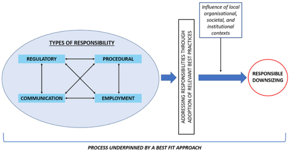

NOTE: figure/graphic rendered as an image from the PDF; its content is not machine-readable text. Caption (if any) follows as the next block.

and can be mutually reinforcing, meaning responsible downsizing can arguably be understood as all four being addressed in combination. The types of responsibility represent four key factors in the framework. These are not discrete or static phenomena and responsibilities may work in tandem as certain practices address one or more when implemented.

For example, consultation periods reflect regulatory and procedural responsibilities but also contribute to communication and employment responsibilities if proactively engaged in a meaningful and substantive way by organisations. Similarly, internal redeployment may be a regulatory requirement in some countries yet also offers organisations the opportunity to address their employment responsibilities by avoiding compulsory redundancies. The framework therefore opens the possibility for organisations to realise the potential interconnectedness of different types of responsibility when implementing responsible downsizing.

The framework also illustrates some guidelines for organisations conducting responsible downsizing. In addressing types of responsibility, organisations can consider the most relevant best practices from extant policy, academic or practitioner literature for application to their specific, local downsizing situation. In this sense, the framework does not instruct organisations to eschew the utility of best practices but instead posits a best fit approach that recognises the differential impact of their application. The intention is to gear organisations towards how an application of best practices is informed by organisational, societal and institutional factors by affording primacy to how practices accord with different types of responsibility in different contexts. In this sense, contextual settings are important because different types of responsibility will reflect deeply embedded values, beliefs or norms, which will help organisations make sense of downsizing practices and their likely effect.

**Figure 1.** A framework for responsible downsizing.

Page 20

34 C. J. MCLACHLAN

Based on the reviewed articles, the influence of contextual variables in responsible downsizing relates, but is not exhaustive, to national industrial relations systems, legal environments, regional labour markets and workforce demographics. In addition, such contextual variables may interact and further shape the potential for responsible downsizing. For example, organisations may go beyond minimal legal requirements because of negotiations with unions or other employee representatives. Similarly, organisations may provide varying standards of retraining and outplacement services depending on the types of opportunities in the local labour market and the skill level of affected employees. Amplifying the role that internal and external contexts play, and especially internationally, can therefore lead to an improved understanding of what is, and is not, considered responsible within an organisation’s particular setting. Responsible downsizing is therefore a contextually-embedded process, rather than set of a universally applicable practices.

The relationship between downsizing practices and the responsibility they represent is thus crucial. Table 5 summarises the responsibilities and practices reviewed in the development of the framework to clarify concrete examples as to how responsible downsizing might be achieved. In this sense, responsible downsizing is premised upon organisations addressing different types of responsibilities. This is in contrast to a rudimentary application of uniform best practices that neither reflect localised contexts and contingencies nor indicate the type of responsibility they aim to address.

#### **Discussion and future research agenda**

Based on a review of empirical articles, this paper has developed a framework for responsible downsizing that is sensitive to the influence of organisational, societal and institutional contexts. The framework is predicated on questioning the assumptions of the prevailing best practice approach. Importantly, a framework for responsible downsizing based

**Table 5.** Summary of responsibilities and practices.

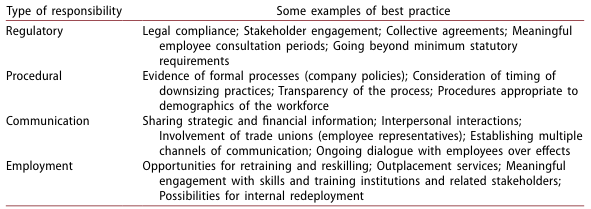

NOTE: complex table shown as an image of the PDF; the text below is a rough machine extraction and may be mis-aligned.

**extracted text (unreliable layout)**

Page 21

The International Journal of Human Resource Management 35

on existing evidence has been lacking in extant HRM literature. In taking stock of what is and is not known about responsible downsizing, the paper contributes to our knowledge of the topic in two key areas.

Firstly, the theoretical focus of the paper is distinct from Bergström (2007) as responsible downsizing is analysed in relation to HR theories of best practice and best fit. Specifically, given Bergström (2007) does not develop a framework for the process, this paper builds on previous work by facilitating insights into what the translation of downsizing best practices to local contexts might look like. Therefore, a key contention of the paper is that a framework theoretically underpinned by a best fit approach offers a more useful way to understand the relationship between responsible downsizing practices and local contexts. This stands in contrast to a dominant focus on best practice toolboxes in the academic and policy literature. While recognising that responsible downsizing is a dynamic process that cannot necessarily be applied anywhere, the framework extends our understanding by positing key tenets to aid organisations in its implementation; as outlined above.

Secondly, the framework refines the blanket notion of ‘responsibility’ evident in the nomenclature of previous studies by substantiating its meaning in relation to downsizing. The framework contributes a nuanced understanding of responsibility in downsizing, stressing the *regulatory, procedural, communication* and *employment* responsibilities of organisations. The development of the framework, formed through a systematic review, deepens our knowledge of the topic by establishing novel insights into the different types of responsibilities organisations are confronted with when downsizing. In doing so, the framework posits that organisations afford primacy to enacting these responsibilities by reflecting on how certain practices might contribute to each type being addressed. Furthermore, this contribution parallels conceptual developments in the CSR literature where different types of responsibility are identified, refining our focus on what responsible downsizing involves.

The analytical development of the framework goes beyond synthesising extant research by abstracting from best practices in the reviewed articles and clustering them into thematic categories based on patterns of responsibility. Analysis focussed on illustrating instances where best practice existed but was adapted, or augmented, because of localised contingencies and contexts. Moreover, the framework corroborates research elsewhere that an essential criterion of responsible downsizing is to ameliorate the negative effects for employees. Organisations may nonetheless have additional economic responsibilities to shareholders when conducting downsizing based on cost-cutting and efficiency concerns, or other responsibilities to unions and stakeholders in the local community.

Page 22

36 C. J. MCLACHLAN

A further implication of the paper relates to how the economic crisis resulting from COVID-19 means downsizing will continue apace. Developing strategies to mitigate the often profound consequences of redundancy is therefore significant and will arguably require organisations to adopt responsible forms of downsizing. The current use of job retention schemes such as short-time working and furloughing in response to the pandemic (Scarpetta et al., 2020) reflect aspects of responsible downsizing given such schemes have helped mitigate some of the associated hardship for employees by preserving employment through an economic crisis. The future of these schemes nevertheless remains an open question and is dependent on decisions made by states and organisations within national contexts.

Against this backdrop, this paper maps three critical areas for future research. Firstly, the framework establishes a schema for future research into responsible downsizing. The framework can be applied to cases of downsizing to evaluate how practices and processes address different types of responsibilities. Applications of the framework may reveal instances of responsible and *irresponsible* downsizing. Documenting examples of both is essential to an ongoing conceptual refinement of the topic. The framework will aid researchers in understanding the scope of what different types of ‘responsibility’ look like in variable downsizing contexts. Furthermore, future research should expand on the overlapping and mutually reinforcing nature of different types of responsibility. This provides an opportunity to explain in more depth the potential causal interactions between responsibilities, which may produce a more dynamic understanding of responsible downsizing.

Page 23

The International Journal of Human Resource Management 37

Thirdly, future research should focus on understanding *to whom* downsizing is responsible. An accepted notion is that responsible downsizing aims to ameliorate the negative effects of redundancies. Nonetheless, there is also research that indicates potential strategic benefits for organisations, such as improved job satisfaction and firm innovation (Tsai & Yen, 2020) or the maintenance of a positive psychological contract (Teague & Roche, 2014). Organisational and employee outcomes may be complementary. However, distinguishing between these outcomes would enhance the critical focus through an evaluation of how practices ostensibly addressing employee concerns may in practice disproportionately serve managerial objectives. For instance, the potential for management to cynically exploit procedural and temporal issues through a superficial framing of downsizing as responsible remains largely underexplored. Management may be more concerned with establishing an *image* of responsibility to the workforce, as opposed to genuinely *acting* responsibly. More substantive concerns for the personal and professional needs of employees, such as retraining or other support services, may be disregarded in favour of ensuring a narrative of ‘responsible’ downsizing (Bergström & Diedrich, 2011). Packaging downsizing as ‘responsible’ may be nothing more than an ‘empty shell’ of a strategy, simply serving organisational goals by preserving their public reputation or obtaining the workforce’s consent to what is often an essentially difficult and unpleasant process.

#### *Implications for practice*

There are three implications for HR practitioners emerging from the framework. Firstly, the framework may act as a heuristic for HR and senior managers tasked with implementing responsible downsizing. Practitioners may consult lists of best practices and reflect on how these aid in addressing each responsibility by adapting practices to their specific organisational context. Practitioners likely already adopt a best fit approach when implementing downsizing: the framework hence recognises complementarities between a best practice and best fit approach (Stavrou et al., 2010). Yet the framework positions the notion of *acting responsibly* as a guiding principle. The intention is to encourage greater reflection on strategies for addressing *responsibilities* during downsizing rather than resorting to a ‘tick box’ exercise concerned with the simple incidence of practices.

Page 24

38 C. J. MCLACHLAN

Secondly, the framework points to a utility in integrating internal and external stakeholders into downsizing processes. As apparent from the reviewed articles, responsible downsizing demands that organisations engage with unions, state officials and training or skills agencies as such actors can contribute to the overall design and implementation of the process. HR practitioners will need to invest in relationships with stakeholders and manage expectations of what is feasible in relation to different types of responsibility: this might involve establishing responsible downsizing committees or ‘task forces’ as a way of coordinating stakeholder interests throughout and beyond the process. However, one challenge facing HR practitioners in managing stakeholder interests is determining the relative importance of different groups as not all stakeholders are necessarily equal. Furthermore, a stakeholder approach may be more common in coordinated market economies, though is also possible more liberal market economies as discussed.

A third implication for HR practitioners lies in the effective management of employees as part of an overall strategic focus on a fair and just approach to downsizing. The framework stresses the importance of addressing the needs of employees, in terms of adopting a responsible approach, but also the potential strategic benefits of doing so. Acknowledging how best practices are enabled by contextual variables, or made vulnerable by them, may be useful for HR practitioners in deciding what is possible when conducting responsible downsizing.

#### **Conclusion**

The principal contribution of this paper is the development of a framework for responsible downsizing, located within HR theories of best practice and best fit. In doing so, the paper contends that responsible downsizing is better understood as theoretically underpinned by a best fit approach. The framework outlines how responsible downsizing might be achieved, building on Bergström’s (2007) notion that downsizing practices must be translated into local contexts if a responsible process is to be assumed. In this sense, the paper questions the assumptions of the prevailing best practice focus in academic and policy downsizing literature. That said, the framework does not reject the need for best practices, but rather advances the argument that responsible downsizing should be seen as a contextually-embedded process rather than the mere incidence of supposed universally applicable best practices. Organisational, societal and institutional factors hence shape the implementation of responsible downsizing. Furthermore, four different types of responsibility placed on organisations during downsizing are identified that nuance our blanket understanding of ‘responsibility’ in previous studies: *regulatory, procedural,*

Page 25

The International Journal of Human Resource Management 39

*communication* and *employment*. The importance of *responsible* downsizing has nonetheless been brought into sharp relief due to the economic crisis and consequential redundancies caused by COVID-19, demanding we deepen our knowledge of the types of practices and processes that mitigate the profound effects of downsizing on affected employees.

#### **Disclosure statement**

No potential conflict of interest was reported by the author.

#### **Data availability statement**

Data sharing is not applicable to this article as no new data were created or analysed in this study.

#### **References**

Ahlstrand, R. (2010). Social responsibility in connection with business closures: A study

of the close-down of Ericsson Telecom facilities in Norrköping and Linköping. *Economic and Industrial Democracy*, *31*(4), 537–555. https://doi.org/10.1177/01438 31X10365926 Auer, P. 2001. *Labour market policy for socially responsible workforce adjustment*.

Employment Sector, International Labour Office: Geneva Barrena-Martínez, J., López-Fernández, M., & Romero-Fernández, P. M. (2019). Towards

a configuration of socially responsible human resource management policies and practices: Findings from an academic consensus. *The International Journal of Human Resource Management*, *30*(17), 2544–2580. https://doi.org/10.1080/09585192.2017.1332669 Bergström, O. (2007). Translating socially responsible workforce reduction—A longi-

tudinal study of workforce reduction in a Swedish company. *Scandinavian Journal of Management*, *23*(4), 384–405. https://doi.org/10.1016/j.scaman.2007.07.001 Bergström, O., & Arman, R. (2017). Increasing commitment after downsizing: The role

of involvement and voluntary redundancies. *Journal of Change Management*, *17*(4), 297–320. https://doi.org/10.1080/14697017.2016.1252784 Bergström, O., & Diedrich, A. (2011). Exercising social responsibility in downsizing:

Enrolling and mobilizing actors at a Swedish high-tech company. *Organization Studies*, *32*(7), 897–919. https://doi.org/10.1177/0170840611407019 Bonvin, J. M. (2007). Corporate social responsibility in a context of permanent re-

structuring: A case study from the Swiss metalworking sector. *Corporate Governance: An International Review*, *15*(1), 36–44. https://doi.org/10.1111/j.1467-8683.2007.00540.x Bracker, J. S., & Kinicki, A. J. (1988). Strategic management, plant closings, and social

responsibility: An integrative process model. *Employee Responsibilities and Rights Journal*, *1*(3), 201–213. https://doi.org/10.1007/BF01384981 Brockner, J. (1992). Managing the effects of layoffs on survivors. *California Management*

*Review*, *34*(2), 9–28. https://doi.org/10.2307/41166691 Brockner, J., Spreitzer, G., Mishra, A., Hochwarter, W., Pepper, L., & Weinberg, J. (2004).

Perceived control as an antidote to the negative effects of layoffs on survivors’ or-

Page 26

40 C. J. MCLACHLAN

ganizational commitment and job performance. *Administrative Science Quarterly*, *49*(1), 76–100. https://doi.org/10.2307/4131456 Carroll, A. B. (1984). When business closes down: Social responsibilities and manage-

ment actions. *California Management Review*, *26*(2), 125–140. https://doi. org/10.2307/41165072 Carroll, A. B., & Shabana, K. M. (2010). The business case for corporate social respon-

sibility: A review of concepts, research and practice. *International Journal of Management Reviews*, *12*(1), 85–105. https://doi.org/10.1111/j.1468-2370.2009.00275.x Cascio, W. F. (2002). Strategies for responsible restructuring. *Academy of Management*

*Perspectives*, *16*(3), 80–91. https://doi.org/10.5465/ame.2002.8540331 CEDEFOB. (2010). *Socially responsible restructuring: Effective strategies for supporting*

*redundant workers*. Luxembourg: European Centre for the Development of Vocational Training: Cooke, F. L. (2018). Concepts, contexts, and mindsets: Putting human resource man-

agement research in perspectives. *Human Resource Management Journal*, *28*(1), 1–13. https://doi.org/10.1111/1748-8583.12163 Cooke, F. L., Dickmann, M., & Parry, E. (2020). IJHRM after 30 years: Taking stock

in times of COVID-19 and looking towards the future of HR research. *The International Journal of Human Resource Management*, *31*(1), 1–23. https://doi.org/1 0.1080/09585192.2020.1691353 Cullinane, N., & Dundon, T. (2006). The psychological contract: A critical review.

*International Journal of Management Reviews*, *8*(2), 113–129. https://doi.org/10.1111/ j.1468-2370.2006.00123.x De Vries, M. F. K., & Balazs, K. (1997). The downside of downsizing. *Human Relations*,

*50*(1), 11–50. https://doi.org/10.1177/001872679705000102 De Witte, H., Vandoorne, J., Verlinden, R., & De Cuyper, N. (2005). Outplacement and

re‐employment measures during organizational restructuring in Belgium. *Journal of European Industrial Training*, *29*(2), 148–164. https://doi.org/10.1108/03090590510585109 Dobbins, T., Plows, A., & Lloyd-Williams, H. (2014). Make do and mend’ after redun-

dancy at Anglesey Aluminium: Critiquing human capital approaches to unemployment. *Work, Employment and Society*, *28*(4), 515–532. https://doi.org/10.1177/0950017013491454 Doherty, N., Tyson, S., & Viney, C. (1993). A positive policy? Corporate perspectives

on redundancy and outplacement. *Personnel Review*, *22*(7), 45–53. https://doi. org/10.1108/00483489310047964 Eby, L. T., & Buch, K. (1998). The impact of adopting an ethical approach to employ-

ee dismissal during corporate restructuring. *Journal of Business Ethics*, *17*(12), 1253– 1264. https://doi.org/10.1023/A:1005758628414 EC. (2009). *Toolkits for restructuring based on the innovative actions of European Social*

*Fund Article 6 projects*. European Commission, Employment, Social Affairs and Equal Opportunities: Brussels Evans-Klock, C., Kelly, P., Richards, P., & Vargha, C. (1998). *Worker displacement: Public*

*policy and labour-management initiatives in selected OECD countries*. ILO. Forde, C., Stuart, M., Gardiner, J., Greenwood, I., MacKenzie, R., & Perrett, R. (2009).

*Socially responsible restructuring in an era of mass redundancy. University of Leeds: CERIC Working Papers Series*. Centre for Employment Relations Innovation and Change. Garaudel, P., Beaujolin, R., Noël, F., & Schmidt, G. (2016). Understanding the pathways

to above-mandatory severance pay when downsizing: A qualitative comparative analysis of 20 cases in France. *Relations Industrielles*, *71*(1), 80–108. https://doi. org/10.7202/1035903ar

Page 27

The International Journal of Human Resource Management 41

Garaudel, P., Noël, F., & Schmidt, G. (2008). Overcoming the risks of restructuring

through the integrative bargaining process: Two case studies in a French context. *Human Relations*, *61*(9), 1293–1331. https://doi.org/10.1177/0018726708094913 Gardiner, J., Stuart, M., MacKenzie, R., Forde, C., Greenwood, I., & Perrett, R. (2009).

Redundancy as a critical life event: Moving on from the Welsh steel industry through career change. *Work, Employment and Society*, *23*(4), 727–745. https://doi. org/10.1177/0950017009344917 Gilliland, S. W., & Schepers, D. H. (2003). Why we do the things we do: A discussion

and analysis of determinants of just treatment in layoff implementation decisions. *Human Resource Management Review*, *13*(1), 59–83. https://doi.org/10.1016/ S1053-4822(02)00099-2 Hansen, G. B. (2009). *A guide to worker displacement: Some tools for reducing the impact*

*on workers, communities and enterprises*. Skills and Employability Department, ILO. Harney, B., Fu, N., & Freeney, Y. (2018). Balancing tensions: Buffering the impact of

organisational restructuring and downsizing on employee well‐being. *Human Resource Management Journal*, *28*(2), 235–254. https://doi.org/10.1111/1748-8583.12175 Hopkins, W. E., & Hopkins, S. A. (1999). The ethics of downsizing: Perceptions of

rights and responsibilities. *Journal of Business Ethics*, *18*(2), 145–155. https://doi. org/10.1023/A:1005908411641 Johnstone, S. (2019). Employment practices, labour flexibility and the Great Recession:

An automotive case study. *Economic and Industrial Democracy*, *40*(3), 537–559. https://doi.org/10.1177/0143831X17748370 Kernan, M. C., & Hanges, P. J. (2002). Survivor reactions to reorganization: Antecedents

and consequences of procedural, interpersonal, and informational justice. *The Journal of Applied Psychology*, *87*(5), 916–928. https://doi.org/10.1037/0021-9010.87.5.916 Kieselbach, T., & Mader, S. (2002). Occupational transitions and corporate responsi-

bility in layoffs: A European research project (SOCOSE). *Journal of Business Ethics*, *39*(1/2), 13–20. https://doi.org/10.1023/A:1016315530823 Kim, H. S. (2009). Examining the role of informational justice in the wake of down-

sizing from an organizational relationship management perspective. *Journal of Business Ethics*, *88*(2), 297–312. https://doi.org/10.1007/s10551-008-9964-0 Kirov, V. N., & Thill, P. (2018). The impact of crisis and restructuring on employment

relations in banking: The cases of France, Luxembourg and Romania. *European Journal of Industrial Relations*, *24*(3), 297–313. https://doi.org/10.1177/0959680117752047 Lakshman, C., Ramaswami, A., Alas, R., Kabongo, J. F., & Pandian, J. R. (2014). Ethics

trumps culture? A cross-national study of business leader responsibility for downsizing and CSR perceptions. *Journal of Business Ethics*, *125*(1), 101–119. https://doi. org/10.1007/s10551-013-1907-8 Lansing, P. A., & Van Buren, H. J. (1993). Downsizing: Is there on ethical dimension

to a partial plant closing?*Labor Law Journal*, *44*(11), 697. Long, B. S. (2012). The irresponsible enterprise: The ethics of corporate downsizing.

In Tench, R., Sun, W. and Jones, B. (Ed.), *Corporate social irresponsibility: A challenging concept* (Critical Studies on Corporate Responsibility, Governance and Sustainability, Vol. 4, pp. 295-315) Bingley: Emerald Group Publishing Limited. https://doi.org/10.1108/S2043-9059(2012)0000004021. López Bohle, S. A., Chambel, M. J., & Diaz-Valdes Iriarte, A. (2021). Job insecurity,

procedural justice and downsizing survivor affects. *The International Journal of Human Resource Management*, *32*(3), 596–615. https://doi.org/10.1080/09585192.2018.1482939 Mäkelä, H., & Näsi, S. (2010). Social responsibilities of MNCs in downsizing operations.

*Accounting, Auditing & Accountability Journal*, *23*(2), 149–174. https://doi. org/10.1108/09513571011023174

Page 28

42 C. J. MCLACHLAN

Marchington, M., & Grugulis, I. (2000). Best practice’ human resource management:

Perfect opportunity or dangerous illusion?*The International Journal of Human Resource Management*, *11*(6), 1104–1124. https://doi.org/10.1080/09585190050177184 MIRE. (2006). *Monitoring restructuring in Europe – Summary and recommendations*.

European Commission. McMahon, T. F. (1999). From social irresponsibility to social responsiveness: The

Chrysler/Kenosha plant closing. *Journal of Business Ethics*, *20*(2), 101–111. McKinley, W., Zhao, J., & Rust, K. G. (2000). A sociocognitive interpretation of orga-

nizational downsizing. *Academy of Management Review*, *25*(1), 227–243. https://doi. org/10.5465/amr.2000.2791612 McLachlan, C. J., Greenwood, I., & MacKenzie, R. (2021). Victims, survivors and the

emergence of ‘endurers’ as a reflection of shifting goals in the management of redeployment. *Human Resource Management Journal*, *31*(2), 438–453. https://doi. org/10.1111/1748-8583.12314 Millspaugh, P. E. (1990). Plant closing ethics root in American law. *Journal of Business*

*Ethics*, *9*(8), 665–670. https://doi.org/10.1007/BF00383393 Naumann, S. E., Bies, R. J., & Martin, C. L. (1995). The roles of organizational support

and justice during a layoff. *Academy of Management Proceedings*, *1995*(1), 89–93. https://doi.org/10.5465/ambpp.1995.17536322 Orlando, J. (1999). The fourth wave: The ethics of corporate downsizing. *Business Ethics*

*Quarterly*, *9*(2), 295–314. https://doi.org/10.2307/3857476 Papadakis, K. (2010). *Restructuring enterprises through social dialogue: Socially respon-*

*sible practices in times of crisis*. ILO. Pfeifer, C. (2007). The perceived fairness of layoffs in Germany: Participation, com-

pensation, or avoidance?*Journal of Business Ethics*, *74*(1), 25–36. https://doi.org/10.1007/ s10551-006-9217-z Pulignano, V. (2011). Bringing labour markets ‘back in’: Restructuring international

businesses in Europe. *Economic and Industrial Democracy*, *32*(4), 655–677. https:// doi.org/10.1177/0143831X10392395 Pulignano, V., & Stewart, P. (2013). Firm-level restructuring and union strategies in

Europe: Local union responses in Ireland, Italy and the Netherlands. *Work, Employment and Society*, *27*(5), 842–859. https://doi.org/10.1177/0950017013482028 Purcell, J. (1999). Best practice and best fit: Chimera or cul-de-sac?*Human Resource*

*Management Journal*, *9*(3), 26–41. https://doi.org/10.1111/j.1748-8583.1999.tb00201.x Rogovsky, N., Ozoux, P., & Esser, D. (2005). *Restructuring for corporate success: A*

*socially sensitive approach*. ILO. Rydell, A., & Wigblad, R. (2011). Company-level flexicurity during the restructuring

process: A model. *Transfer: European Review of Labour and Research*, *17*(4), 547–562. https://doi.org/10.1177/1024258911419781 Rydell, A., & Wigblad, R. (2012). The quest for CSR in closedowns. *Nordic Journal of*

*Working Life Studies*, *2*(3), 143–160. https://doi.org/10.19154/njwls.v2i3.2368 Sahdev, K., Vinnicombe, S., & Tyson, S. (1999). Downsizing and the changing role of

HR. *The International Journal of Human Resource Management*, *10*(5), 906–923. https://doi.org/10.1080/095851999340224 Scarpetta, S., Pearson, M., Hijzen, A., & Salvatori, A. (2020, August 3). Job retention

schemes during the COVID-19 lockdown and beyond. *OECD Policy Responses to Coronavirus (COVID-19)*. http://www.oecd.org/coronavirus/policy-responses/ job-retention-schemes-during-the-covid-19-lockdown-and-beyond-0853ba1d/ Scherer, A. G., & Palazzo, G. (2007). Toward a political conception of corporate re-

sponsibility: Business and society seen from a Habermasian perspective. *Academy of Management Review*, *32*(4), 1096–1120. https://doi.org/10.5465/amr.2007.26585837

Page 29

The International Journal of Human Resource Management 43

Settles, M. F. (1988). Humane downsizing: Can it be done? *Journal of Business Ethics*,

*7*(12), 961–963. Sharif, M. M., & Scandura, T. A. (2014). Do perceptions of ethical conduct matter

during organizational change? Ethical leadership and employee involvement. *Journal of Business Ethics*, *124*(2), 185–196. https://doi.org/10.1007/s10551-013-1869-x Snell, D., & Gekara, V. (2020). Unions and corporate social responsibility in a liberal

market context: The case of Ford’s shutdown in Australia. *Journal of Industrial Relations*, *62*(5), 713–734. https://doi.org/10.1177/0022185619896383 Stavrou, E. T., Brewster, C., & Charalambous, C. (2010). Human resource management

and firm performance in Europe through the lens of business systems: Best fit, best practice or both?*The International Journal of Human Resource Management*, *21*(7), 933–962. https://doi.org/10.1080/09585191003783371 Stengård, J., Bernhard-Oettel, C., Näswall, K., Ishäll, L., & Berntson, E. (2015).

Understanding the determinants of well-being and organizational attitudes during a plant closure: A Swedish case study. *Economic and Industrial Democracy*, *36*(4), 611–631. https://doi.org/10.1177/0143831X14527775 Stuart, M., Forde, C., MacKenzie, R., & Wallis, E. (2007). *An impact study on relocation,*

*restructuring, and the viability of the European Globalisation Adjustment Fund: The impact on employment, working conditions and regional development*. EC. Tanner, G., & Otto, K. (2016). Superior–subordinate communication during organiza-

tional change: Under which conditions does high-quality communication become important?*The International Journal of Human Resource Management*, *27*(19), 2183– 2201. https://doi.org/10.1080/09585192.2015.1090470 Teague, P., & Roche, W. K. (2014). Recessionary bundles: HR practices in the Irish

economic crisis. *Human Resource Management Journal*, *24*(2), 176–192. https://doi. org/10.1111/1748-8583.12019 Stjernberg, T. and Tillberg, U.(1998). When structure and meaning break down taking

responsibility in downsizing. *European Journal of Work and Organizational Psychology*, *7*(3), 355–371. https://doi.org/10.1080/135943298398754 Tourish, D., Paulsen, N., Hobman, E., & Bordia, P. (2004). The downsides of downsiz-

ing: Communication processes information needs in the aftermath of a workforce reduction strategy. *Management Communication Quarterly*, *17*(4), 485–516. https:// doi.org/10.1177/0893318903262241 Tracy, S. J. (2019). *Qualitative research methods: Collecting evidence, crafting analysis,*

*communicating impact*. John Wiley & Sons. Tranfield, D., Denyer, D., & Smart, P. (2003). Towards a methodology for developing

evidence‐informed management knowledge by means of systematic review. *British Journal of Management*, *14*(3), 207–222. https://doi.org/10.1111/1467-8551.00375 Trevor, C. O., & Nyberg, A. J. (2008). Keeping your headcount when all about you are

losing theirs: Downsizing, voluntary turnover rates, and the moderating role of HR practices. *Academy of Management Journal*, *51*(2), 259–276. https://doi.org/10.5465/ amj.2008.31767250 Tsai, P. C. F., & Shih, C. T. (2013a). Labor union negotiations: Stepping stones or

stumbling blocks for a responsible downsizing strategy? Empirical tests in Taiwan. *The International Journal of Human Resource Management*, *24*(3), 601–620. https:// doi.org/10.1080/09585192.2012.694112 Tsai, P. C. F., & Shih, C. T. (2013b). Responsible downsizing strategy as a panacea to

firm performance: The role of dynamic capabilities. *International Journal of Manpower*, *34*(8), 1015–1028. https://doi.org/10.1108/IJM-07-2013-0170

Page 30

44 C. J. MCLACHLAN

Tsai, C. F., & Yen, Y. F. (2020). Moderating effect of employee perception of respon-

sible downsizing on job satisfaction and innovation commitment. *The International Journal of Human Resource Management*, *31*(15), 1913–1937. https://doi.org/10.1080 /09585192.2018.1424014 Turnbull, P., & Wass, V. (1997). Job insecurity and labour market lemons: The (mis)

management of redundancy in steel making, coal mining and port transport. *Journal of Management Studies*, *34*(1), 27–51. https://doi.org/10.1111/1467-6486.00041 Turnley, W. H., & Feldman, D. C. (1998). Psychological contract violations during

corporate restructuring. *Human Resource Management*, *37*(1), 71–83. https://doi. org/10.1002/(SICI)1099-050X(199821)37:1<71::AID-HRM7>3.0.CO;2-S Van Buren, H. J. (2000). The bindingness of social and psychological contracts: Toward

a theory of social responsibility in downsizing. *Journal of Business Ethics*, *25*(3), 205–219. Van Dierendonck, D., & Jacobs, G. (2012). Survivors and victims, a meta‐analytical

review of fairness and organizational commitment after downsizing. *British Journal of Management*, *23*(1), 96–109. Vuontisjärvi, T. (2013). Argumentation and socially questionable business practices:

The case of employee downsizing in corporate annual reports. *Scandinavian Journal of Management*, *29*(3), 292–313. https://doi.org/10.1016/j.scaman.2013.01.003 Watson, G. W., Shepard, J. M., Stephens, C. U., & Christman, J. C. (1999). Ideology

and the economic social contract in a downsizing environment. *Business Ethics Quarterly*, *9*(4), 659–672. https://doi.org/10.2307/3857942